# Model Validation

Lorenzo Leme

## Creating your Data

Remember the rules…

### Rules

1. Your csv must contain 11 columns of data.
   - The first column must be your (1) Y-variable (labeled as “Y”).
   - The other ten columns must be (10) X-variables (labeled as “X1”, “X2”, … , “X10”).
2. Your Y-variable (or some transformation of the Y-variable) must have been created from a linear regression model using only X-variables (or transformations of those X-variables) from within your data set.
   - Be very careful with transformations. You must ensure that you do not break the rules of a linear regression if you choose to use transformations.
   - If you choose transformations, only these functions are allowed when transforming X and Y variables: 1/Y^2, 1/Y, log(Y), sqrt(Y), Y^2, Y^3, 1/X^2, 1/X, log(X), sqrt(X), X^2, X^3, X^4, X^5. Don’t forget to check Rule #3 carefully if you choose transformations.
3. Your sample size must be sufficiently large so that when the true model is fit to your data using lm(…), all p-values of X-variable terms (not including the intercept) found in the summary(…) are significant.

### True Model

Write out your final “true” model in mathematical form. Make sure it matches your code.

$$\text{EXAMPLE:} \ Y_i = \beta_0 + \beta_1 X_{1i} + \beta_2 X_{1i}^2 + \beta_3 X_{2i} + \beta_4 X_{1i}X_{2i} + \beta_5 X_{1i}^2X_{2i} + \beta_6X_{1i}^3X_{2i} + \epsilon_i$$

### The Code to Make the Data

```r
set.seed(122) #This ensures the randomness is the "same" everytime if you play the entire R-chunk as one entire piece of code. If you run lines separately, your data might not come out the same every time.

## To begin, decide on your sample size. (You may have to revise it later to ensure all values in your lm(...) are significant.)

 n <- 60

## Then, create 10 X-variables using functions like rnorm(n, mean, sd), rchisq(n, df), rf(n, df1, df2), rt(n, df), rbeta(n, a, b), runif(n, a, b) or sample(c(1,0), n, replace=TRUE)...

 X1 <- runif(n, -80, 50) #replace this
 X2 <- runif(n, 10, 20) #replace this
 X3 <- runif(n, 120, 180) #replace this
 X4 <- sample(c(1,0), n, replace=TRUE) #replace this
 X5 <- runif(n, 180, 200) #replace this
 X6 <- sample(c(1,0), n, replace=TRUE) #replace this
 X7 <- sample(c(1,0), n, replace=TRUE) #replace this
 X8 <- runif(n, 43, 69) #replace this
 X9 <- sample(c(1,0), n, replace=TRUE) #replace this
 X10 <- runif(n, 40, 90) #replace this

## Then, create betas, errors (by choosing sigma), and Y

beta0 <- 2

beta1 <- 2

beta2 <- -4

beta3 <- -2

beta4 <- -13

beta5 <- 5

beta6 <- 3

sigma <- 5 #change to whatever you want


 ################################
 # You CANNOT change this part:
 errors <- rnorm(n, 0, sigma)
 ################################

 #An example of how to make Y...
 # Y <-  beta0 + beta1*X1 + beta2*X2 + beta3*X4*X2 + errors

Y <- beta0 + beta1 * X1 + beta2 * X1^2 + beta3 * X2 + beta4 * X1 * X2 + beta5 * X1^2 * X2 + beta6 * X1^3 * X2 + errors #Change if you want, but this matches our stated mathematic model from above.

  #...edit this code and replace it with your model

 # You can include Y' or X' instead of Y or X if you wish.
 # Remember, only these functions are allowed when transforming
 # variables: 1/Y^2, 1/Y, log(Y), sqrt(Y), Y^2, Y^3, 1/X^2, 1/X, log(X), sqrt(X), X^2, X^3, X^4, X^5.
 #########################################################
 # ILLEGAL: Y = (beta0 + beta1*X5)^2 + epsilon ###########
 #########################################################
 # Legal: sqrt(Y) = beta0 + beta1*X5^2 + epsilon #########
 #########################################################
 # You can only transform individual terms, not groups of terms.
 # And the beta's cannot be part of the transformation.


 # Load your data into a data set:
RBdata <- data.frame(Y = Y, X1 = X1, X2 = X2, X3 = X3, X4 = X4, X5 = X5, X6 = X6, X7 = X7, X8 = X8, X9 = X9, X10 = X10)
 #In regression battleship you will have up to X10 included.

 #Now fit your model to make sure it comes out significant:
 true.lm <- lm(Y ~ X1 + I(X1^2) + X6 + X1:X6 + I(X1^2):X6 + I(X1^3):X6, data=RBdata)
 #see if you can get the correct lm.
 #edit this code
 summary(true.lm)
```

```
##
## Call:
## lm(formula = Y ~ X1 + I(X1^2) + X6 + X1:X6 + I(X1^2):X6 + I(X1^3):X6,
##     data = RBdata)
##
## Residuals:
##      Min       1Q   Median       3Q      Max
## -6040514  -494910    40931   856600  3992081
##
## Coefficients:
##               Estimate Std. Error t value Pr(>|t|)
## (Intercept)  1.589e+06  5.116e+05   3.106 0.003047 **
## X1           9.509e+04  1.274e+04   7.463 8.11e-10 ***
## I(X1^2)     -1.809e+03  2.609e+02  -6.933 5.77e-09 ***
## X6          -1.689e+06  8.084e+05  -2.089 0.041520 *
## X1:X6       -9.929e+04  2.796e+04  -3.551 0.000814 ***
## I(X1^2):X6   2.177e+03  6.879e+02   3.165 0.002571 **
## X6:I(X1^3)   5.107e+01  1.069e+01   4.775 1.46e-05 ***
## ---
## Signif. codes:  0 '***' 0.001 '**' 0.01 '*' 0.05 '.' 0.1 ' ' 1
##
## Residual standard error: 2054000 on 53 degrees of freedom
## Multiple R-squared:  0.9285, Adjusted R-squared:  0.9204
## F-statistic: 114.7 on 6 and 53 DF,  p-value: < 2.2e-16
```

```r
 #all p-values must be significant, except "(Intercept)"
```

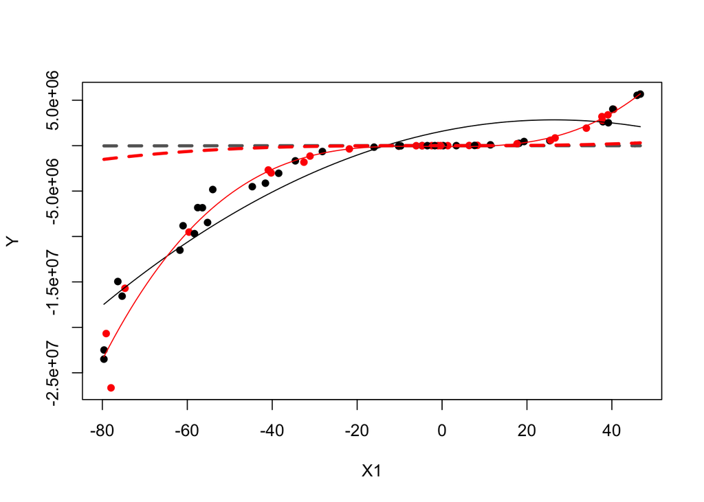

```r
plot(Y ~ X1, data=RBdata, col=as.factor(X6), pch=16)

b <- coef(true.lm)

curve(b[1]+b[2]*x+b[3]*x^2, add=TRUE, col="black") #add quadratic model

curve((b[1]+b[4])+(b[2]+b[5])*x + (b[3]+b[6])*x^2 + b[7]*x^3, add=TRUE, col="red") #add cubic model, hint, this one uses all coefficients.



# Then use curve twice again, but with your original beta's to show the "TRUE" model in dashed lines on the same plot.


curve(beta0 + beta1*x + beta2*x^2, add=TRUE, col="grey40", lty=2, lwd=3)

curve((beta0 + beta3) + (beta1 + beta4)*x + (beta2 + beta5)*x^2 + beta6*x^3, add=TRUE, lty=2, lwd=3, col="red")
```

```r
# Once you are ready, run this code to write your data to a csv:
write.csv(RBdata, "RBdata.csv", row.names=FALSE)
# The above code writes the dataset to your "current directory"
# To see where that is, use: getwd() in your Console.
# Find the data set and upload it to I-Learn.
```

```r
set.seed(15) #This ensures the randomness is the "same" everytime if you play the entire R-chunk as one entire piece of code. If you run lines separately, your data might not come out the same every time.

## To begin, decide on your sample size. (You may have to revise it later to ensure all values in your lm(...) are significant.)

 n <- 60

## Then, create 10 X-variables using functions like rnorm(n, mean, sd), rchisq(n, df), rf(n, df1, df2), rt(n, df), rbeta(n, a, b), runif(n, a, b) or sample(c(1,0), n, replace=TRUE)...

 X1 <- runif(n, -80, 50) #replace this
 X2 <- runif(n, 10, 20) #replace this
 X3 <- runif(n, 120, 180) #replace this
 X4 <- sample(c(1,0), n, replace=TRUE) #replace this
 X5 <- runif(n, 180, 200) #replace this
 X6 <- sample(c(1,0), n, replace=TRUE) #replace this
 X7 <- sample(c(1,0), n, replace=TRUE) #replace this
 X8 <- runif(n, 43, 69) #replace this
 X9 <- sample(c(1,0), n, replace=TRUE) #replace this
 X10 <- runif(n, 40, 90) #replace this

## Then, create betas, errors (by choosing sigma), and Y

beta0 <- 2

beta1 <- 2

beta2 <- -4

beta3 <- -2

beta4 <- -13

beta5 <- 5

beta6 <- 3

sigma <- 5 #change to whatever you want


 ################################
 # You CANNOT change this part:
 errors <- rnorm(n, 0, sigma)
 ################################

 #An example of how to make Y...
 # Y <-  beta0 + beta1*X1 + beta2*X2 + beta3*X4*X2 + errors

Y <- beta0 + beta1 * X1 + beta2 * X1^2 + beta3 * X2 + beta4 * X1 * X2 + beta5 * X1^2 * X2 + beta6 * X1^3 * X2 + errors #Change if you want, but this matches our stated mathematic model from above.

  #...edit this code and replace it with your model

 # You can include Y' or X' instead of Y or X if you wish.
 # Remember, only these functions are allowed when transforming
 # variables: 1/Y^2, 1/Y, log(Y), sqrt(Y), Y^2, Y^3, 1/X^2, 1/X, log(X), sqrt(X), X^2, X^3, X^4, X^5.
 #########################################################
 # ILLEGAL: Y = (beta0 + beta1*X5)^2 + epsilon ###########
 #########################################################
 # Legal: sqrt(Y) = beta0 + beta1*X5^2 + epsilon #########
 #########################################################
 # You can only transform individual terms, not groups of terms.
 # And the beta's cannot be part of the transformation.


 # Load your data into a data set:
RBdata2 <- data.frame(Y = Y, X1 = X1, X2 = X2, X3 = X3, X4 = X4, X5 = X5, X6 = X6, X7 = X7, X8 = X8, X9 = X9, X10 = X10)
 #In regression battleship you will have up to X10 included.

 #Now fit your model to make sure it comes out significant:
 true.lm <- lm(Y ~ X1 + I(X1^2) + X6 + X1:X6 + I(X1^2):X6 + I(X1^3):X6, data=RBdata)
 #see if you can get the correct lm.
 #edit this code
 summary(true.lm)
```

```
##
## Call:
## lm(formula = Y ~ X1 + I(X1^2) + X6 + X1:X6 + I(X1^2):X6 + I(X1^3):X6,
##     data = RBdata)
##
## Residuals:
##      Min       1Q   Median       3Q      Max
## -6040514  -494910    40931   856600  3992081
##
## Coefficients:
##               Estimate Std. Error t value Pr(>|t|)
## (Intercept)  1.589e+06  5.116e+05   3.106 0.003047 **
## X1           9.509e+04  1.274e+04   7.463 8.11e-10 ***
## I(X1^2)     -1.809e+03  2.609e+02  -6.933 5.77e-09 ***
## X6          -1.689e+06  8.084e+05  -2.089 0.041520 *
## X1:X6       -9.929e+04  2.796e+04  -3.551 0.000814 ***
## I(X1^2):X6   2.177e+03  6.879e+02   3.165 0.002571 **
## X6:I(X1^3)   5.107e+01  1.069e+01   4.775 1.46e-05 ***
## ---
## Signif. codes:  0 '***' 0.001 '**' 0.01 '*' 0.05 '.' 0.1 ' ' 1
##
## Residual standard error: 2054000 on 53 degrees of freedom
## Multiple R-squared:  0.9285, Adjusted R-squared:  0.9204
## F-statistic: 114.7 on 6 and 53 DF,  p-value: < 2.2e-16
```

```r
 #all p-values must be significant, except "(Intercept)"
```

### Model validation of guesses

These were the three guesses and the true model

Keith: Y ~ I(X1^3) + I(X1^3):X6 + I(X1^5):X6

Mariah: sqrt(Y) ~ X1 + X1:X6 + I(X1^3):X6

Brother. Saunders: Y ~ I(X1^3):X2 + I(X1^2):X2 + X1:X2

```r
#All the lm's

lm.student1 <- lm(Y ~ I(X1^3) + I(X1^3):X6 + I(X1^5):X6, data = RBdata)

lm.student2 <- lm(sqrt(Y) ~ X1 + X1:X6 + I(X1^3):X6, data = RBdata)
lm.s <- lm(Y ~ I(X1^3):X2 + I(X1^2):X2 + X1:X2, data = RBdata)

#true.lm

yht <- predict(lm.student1, newdata=RBdata2)

yhs <- predict(lm.student2, newdata=RBdata2)

yhc <- predict(lm.s, newdata=RBdata2)

ybar <- mean(RBdata2$Y)

SSTO <- sum( (RBdata2$Y - ybar)^2 )

SSEt <- sum( (RBdata2$Y - yht)^2 )

SSEs <- sum( (RBdata2$Y - yhs)^2 )

SSEc <- sum( (RBdata2$Y - yhc)^2 )

rst <- 1 - SSEt/SSTO

rss <- 1 - SSEs/SSTO

rsc <- 1 - SSEc/SSTO

n <- length(RBdata2$Y)

pl <- length(coef(true.lm))

pt <- length(coef(lm.student1))

ps <- length(coef(lm.student2))

pc <- length(coef(lm.s))

rska <- 1 - (n-1)/(n-pt)*SSEt/SSTO

rsta <- 1 - (n-1)/(n-pt)*SSEt/SSTO

rssa <- 1 - (n-1)/(n-ps)*SSEs/SSTO

rsca <- 1 - (n-1)/(n-pc)*SSEc/SSTO
```

[output not shown]

According to the adjusted R squareds of the model validation, we can see that Brother Saunders won with the lowest change in R squareds. However no one found the true model, instead brother Saunders was able to find a model that fit better than the true model according to his R squared of 1 and .99. This was very confusing to me since the true model was significant in every X variable.